# Partitioned Local Depth (PaLD) Community Analyses in R

Partitioned Local Depth (PaLD) is a framework for holistic consideration of community structure for distance-based data. This paper describes an R package, pald, for calculating Partitioned Local Depth (PaLD) probabilities, implementing community analyses, determining community clusters, and creating data visualizations to display community structure. We present essentials of the PaLD approach, describe how to use the pald package, walk through several examples, and discuss the method in relation to commonly used techniques.

Lucy D’Agostino McGowan (Wake Forest University) , Katherine Moore (Amherst College) , Kenneth S. Berenhaut (Wake Forest University)  
2025-09-24

#### Introduction

Partitioned Local Depth (PaLD) is a framework for holistic consideration of community structure for distance-based data. Leveraging a socially inspired perspective, the approach provides network-based community information which is founded on new measures of local depth and pairwise cohesion (partitioned local depth). The method does not require distributional assumptions, optimization criteria, nor extraneous inputs. A complete description of the perspective, together with a discussion of the underlying social motivation, theoretical results, and applications to additional data sets is provided in 1. A brief technical description is included below, directly following the introduction.

As suggested in 1, a main goal of PaLD is to “transform input dissimilarity comparisons into output pairwise relationship strengths (or cohesion) and resulting weighted networks”. This is intended to provide within- and between-community structural information which goes beyond simple cluster labeling. Building on existing approaches to (global) depth, local depth expresses features of centrality via an interpretable probability which is free of parameters and robust to outliers. Partitioning the probabilities which define local depth, we then obtain a measure of cohesion between pairs of individuals. Both local depth and cohesion reflect aspects of relative position (rather than absolute distance) and provide a straightforward way to account for varying density across the space. As shown in 1, provided that two sets are separated (in the sense that the minimum between-set distance is greater than the maximum within-set distance), cohesion is invariant under the contraction and dilation of the distances within each set. This property may be particularly valuable when one has reason to believe that there is heterogeneity in density across the space.

As cohesion captures a sense of the relationship strength between points, we can then analyze and visualize the resulting community structure via a network whose edges are weighted by (mutual) cohesion. The underlying social framework motivates a straightforward yet elegant threshold for distinguishing between strongly and weakly cohesive pairs.

Networks obtained from cohesion can be displayed using a force-directed graph drawing algorithm; here we will graphically emphasize the strong ties (colored by connected component). We refer to the connected components of the network of strong ties as community “clusters”. Note that to qualify as a cluster in this definition, one may not have any strong ties with those outside the cluster, and thus the existence of disjoint groups is a strong signal for separation. Here, clusters are identified without additional user inputs nor optimization criteria. If one wishes to further break the community graph into groups, one may consider using community detection methods (such as spectral clustering or the Louvain algorithm), as available, say, in the [**igraph**](https://CRAN.R-project.org/package=igraph) package. The collection of strong ties may be used in place of (weighted) $k$-nearest neighbors in settings such as classification and smoothing. Overall, the structural information obtained from local depth, cohesion and community graphs can provide a holistic perspective to the data which does not require the use of distributional assumptions, optimization criteria nor additional user inputs.

It is important to emphasize at the outset that community analyses go beyond simple cluster labeling to address intra- and inter-cluster structure, and can supplement results from other methods for clustering, embedding, data depth, nearest neighbors, etc. In addition, the method does not require distributional assumptions, optimization criteria, nor extraneous inputs. Theoretical considerations (see 1) and examples point to distinctive properties that assist in considerations of complex data, in particular with respect to varying density and high dimensions. See the section Cultural and Psychological distance analysis, below, for some discussion in the context of density-based methods.

After a brief introduction to the partitioned local depth approach (including a concrete and instructive example), below, we present a new package, [**pald**](https://CRAN.R-project.org/package=pald), for calculating partitioned local depths, implementing community analyses, and creating data visualizations to display community structure. This paper describes how to use the package, walks through several examples, and contrasts the method results with commonly used techniques. Together, these demonstrate both the novelty of the method and utility of the implementation in the package described.

#### The partitioned local depth approach

The PaLD methodology as introduced in 1 offers a parameter-free approach to analyzing community structure in distance-based data. First, consider a ground set $\mathcal{S}$ equipped with a meaningful measure of pairwise distance (or dissimilarity), $d:\mathcal{S}\times S\rightarrow \mathbb{R}\cup \infty$. We require only that $d$ satisfies the requirements that for all $x,y\in S$ with $y\neq x$,

$$\begin{aligned}
d(x,x) \leq d(y,x) ~~~~and~~~~ d(x,x)< d(x,y).
\end{aligned} \tag{1}$$
Note that $d$ need not necessarily be symmetric nor positive (see (i) below).

We begin with a concept formalizing locality to a pair. For any pair $(x, y)\in \mathcal{S}\times \mathcal{S}$, the *local focus*, $U_{x,y}$ (illustrated in Figure 1 for two-dimensional Euclidean data) is defined via

$$\begin{aligned}
U_{x,y} \stackrel{\text{def}}{=} \{ z \in S \mid d(z,x) \leq d(y,x) \text{ or } d(z,y) \leq d(x,y) \}. \label{localfocusdefn}
\end{aligned} \tag{2}$$

The set $U_{x,y}$ is comprised of elements that are “locally” relevant to the pair $(x,y)$. Eq. (1) guarantees that both $x$ and $y$ are elements of $U_{x,y}$. For discussion from a social perspective, wherein the data are embedded in a latent social space, see Social Framework in 1. Recall that in (2), the distance $d$ need not be symmetric; leveraging the social perspective, we are interested in the direct closeness of $z$ *to* $x$ and $y$, not the reverse (see also (iv), below).

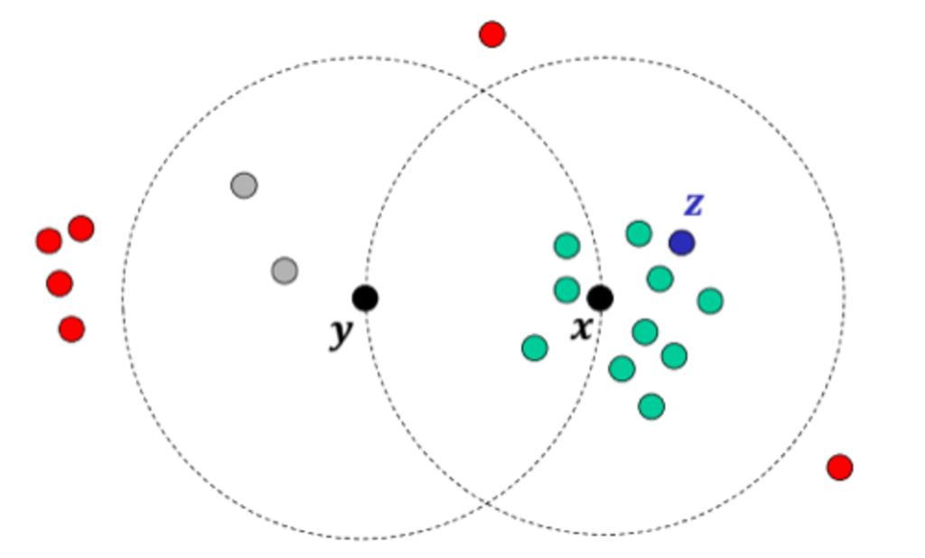

Figure 1: The local focus for two points, $x$ and $y$, where $\mathcal{S}$ is a subset of $\mathbb{R}^2$, under Euclidean distance (reproduced with permission from Berenhaut et al. (2024)). The points in red are outside the focus, $U_{x,y}$. Those in green (and $z$ in blue) are in the focus and closer to $x$, while those in gray are closer to $y$.

Now, suppose that $x$ is fixed, and select $Y$ and $Z$ uniformly at random from $\mathcal{S}\setminus \{x\}$ and $U_{x,Y}$, respectively. The *local depth* of $x$, $\ell_{\mathcal{S}}(x)$, is defined as the probability that $Z$ is closer to $x$ than it is to $Y$ (with a coin flip in the case $Z$ is equidistant), i.e.

$$\begin{aligned}
\ell_{\mathcal{S}}(x)\stackrel{\mathrm{def}}{=}P(d(Z,x) < d(Z,Y)) \label{localdepthdefn}.
\end{aligned} \tag{3}$$

The local depth of $x$ can be thought of as a measure of the extent to which $x$ is (relatively) surrounded by other elements of $\mathcal{S}$ (under $d$).

Finally, the *cohesion*, $C_{x,w}$, of $w$ to $x$, for a given $w\in \mathcal{S}$, is obtained through a partitioning of the probability defining local depth in (3). In particular,

$$\begin{aligned}
C_{x,w} \stackrel{\mathrm{def}}{=}P(Z=w \text{ and } d(Z,x) < d(Z,Y))
\label{cohesdefn}.
\end{aligned} \tag{4}$$

The cohesion of $w$ to $x$ can be viewed as the contribution of $w$ to the local depth of $x$. Eq. (1) guarantees that when $Z=x$, $d(Z,x) < d(Z,Y)$. For some theoretical properties of cohesion, see 1. Note that the sum of all cohesions is conserved at $n/2$, where $n\stackrel{\mathrm{def}}{=}|\mathcal{S}|$; we thus have a constant mean local depth of $0.5$ (independent of $n$).

A universal threshold for strong cohesion (see 1) is defined via

$$\begin{aligned}
T \stackrel{\mathrm{def}}{=}P(Z=W \text{ and } d(Z,X)<d(Z,Y)),
\label{Tsd0}
\end{aligned} \tag{5}$$

where $X$, $Y$, $Z$, and $W$ are selected uniformly at random from $\mathcal{S}$, $\mathcal{S}\setminus X$, $U_{X,Y}$, and $U_{X,Y}$, respectively. The threshold, $T$, can be conveniently calculated as one half the average of the diagonal of the matrix of pairwise cohesion values (see 1 for details), i.e.
$$T = \frac{1}{2} \left( \frac{1}{n} \sum_{x\in \mathcal{S}} C_{x,x} \right).
\label{Tsd} \tag{6}$$
A strong relationship connection between $x$ and $w$ is then established when:
$$\min \{ C_{x,w}, C_{w,x} \} \geq T.
\label{Tsd2} \tag{7}$$

For further details on PaLD, including theoretical results, discussion of the underlying social perspective and applications, see Berenhaut et al. (2022; see also Berenhaut and Moore 2022).

Before moving on to a simple concrete example, we provide a few remarks, for the interested reader, on the concepts introduced above.

1. (Distances and dissimilarities) For the purposes of the package, we require only the inequalities in (1). This implies the convenient form of the threshold in (7) (see Berenhaut et al. 2022), and is crucial to the underlying social perspective of conflict. For a more general mathematical PaLD framework, wherein the concepts of locality and support are further refined (Berenhaut et al. 2024). As the definitions in (2), (3) and (4) only depend on triplet distance comparisons, local depth and cohesion are invariant under monotone transformations of distance, and negative distances are fine. If meaningful in context, distances need not be symmetric and self-distances, $d(x,x)$, may vary over $x$ (subject to the constraint in (1). The triangle inequality may be violated to some extent, mirroring ideas of strong triadic closure (Granovetter 1973).
2. (Local foci) The concept of local foci in (2) is crucial to all that follows. It allows for consideration of the data at varying scales without the need for localizing parameters. The selection of $Z$ in (3) and (4) reflects the larger presence of individuals in smaller foci (see Feld (1981) for discussion is social settings). The results in 1 regarding limiting irrelevance of density and separation under increasing concentration are driven by local comparisons. Self-cohesions (i.e., diagonal elements of $C$) are not necessarily equal. This is driven by the fact that by (4),
   $$\begin{aligned}
   C_{x,x}=\frac{1}{n-1} \sum_{y\neq x} \frac{1}{|{U_{x,y}}|},
   \end{aligned}$$
   and $C_{x,x}$ is dependent on local density around $x$.
3. (Non-monotonicity of the size of local foci) As distance away from an element, $x$, increases, monotonicity in volume of local foci is not necessary. In particular, consider the one-dimensional set $\mathcal{S}=\{B,x,A,C,D\}$, with $B=5$, $x=11$, $A=16$, $C=18$, $D=19$. Under Euclidean distance, $d(x,A)=5<6=d(x,B)$ but $|U_{x,A}|=|\{x,A,C,D\}|=4$ and $|U_{x,B}|=|\{x,B,A\}|=3$. This further emphasizes the capturing of local density, an important feature of PaLD.
4. (Assymmetry) Note that the definitions in (2), (3) and (4) are stated to allow for asymmetric distances, as may occur for instance when considering distances on graphs. Note that even symmetric distances can easily lead to asymmetric cohesion. This is the case even for the simple one-dimensional data considered in Example 1. In considering strong relationships based on cohesion, though, symmetrization is employed in (7).
5. (The use of weighted networks) In what follows, we will at times have occasion to consider a network with node set $\mathcal{S}$ and pairwise edges weighted via the respective values of cohesion. When viewed as a weighted (connectivity) network in this sense,
   1. the weighted nodal degrees are the values of local depth, addressing considerations of (local) data depth,
   2. the network may be embedded in low-dimensional Euclidean space via standard network embedding techniques, providing visualization of the data that adapts to relative density,
   3. the isolated nodes of either the original network or that restricted to strong ties can provide information regarding outliers,
   4. the connected components of the network restricted to strong ties (i.e. those with weights above the threshold in (6) can be taken as “clusters" in the classical sense,
   5. weighted or unweighted network neighbors may be used in place of $k$-nearest neighbors in settings such as classification and smoothing, and
   6. some network analyses can be informative regarding data structure.